# Industry 4.0 의 중심, BigData

Data Processing Based Python @ [FB / jskim.kr](https://www.facebook.com/jskim.kr), [김진수](bigpycraft@gmail.com)

## Sect1. TensorFlow 개요

> TensorFlow™는 데이터 흐름 그래프를 사용하는 수치 연산용 오픈소스 소프트웨어 라이브러리입니다.  
> 그래프의 노드는 수학적 연산을 나타내며, 그래프의 변은 노드 간에 전달되는 다차원 데이터 배열(텐서)을 나타냅니다.  
> 유연한 아키텍처를 채택하여 단일 API를 통해 데스크톱, 서버 또는 휴대기기에 장착된 하나 이상의 CPU 또는 GPU에 연산을 배포할 수 있습니다. TensorFlow는 최초에 Google의 기계지능 연구 조직에 속한 Google Brain팀에서 근무하는 연구자 및 엔지니어에 의해 기계 학습 및 심층신경망 연구용으로 개발되었지만, 기타 분야에도 광범위하게 적용할 수 있는 범용성을 갖춘 시스템입니다.

```python
from tqdm import tqdm_notebook
```

[figure not shown]

```python
bpc.Figure(bpc.LOGO_TF_01, 400)
```

> - [TensorFlow™](https://www.tensorflow.org/get_started/get_started) is an open source software library for numerical computation using data flow graphs.
> - Python!

## TensorFlow updates

> 텐서플로 최신업데이트

Date

Description

[February 15, 2017](https://developers.googleblog.com/2017/02/announcing-tensorflow-10.html)

[September 27, 2016](https://research.googleblog.com/2016/09/a-neural-network-for-machine.html)

### A Neural Network for Machine Translation, at Production Scale

[August 31, 2016](https://research.googleblog.com/2016/08/improving-inception-and-image.html)

### Improving Inception and Image Classification in TensorFlow

[August 30, 2016](https://research.googleblog.com/2016/08/tf-slim-high-level-library-to-define.html)

### TF-Slim: A high level library for complex models in TensorFlow

[August 24, 2016](https://research.googleblog.com/2016/08/text-summarization-with-tensorflow.html)

### Text summarization with TensorFlow

[August 8, 2016](https://research.googleblog.com/2016/08/meet-parseys-cousins-syntax-for-40.html)

### Meet Parsey’s Cousins: Syntax for 40 languages, plus new SyntaxNet capabilities

[June 29, 2016](https://research.googleblog.com/2016/06/wide-deep-learning-better-together-with.html)

### Wide & Deep Learning: Better Together with TensorFlow

[June 27, 2016](https://developers.googleblog.com/2016/06/tensorflow-v09-now-available-with.html)

### TensorFlow v0.9 now available with improved mobile support

[May 12, 2016](http://googleresearch.blogspot.com/2016/05/announcing-syntaxnet-worlds-most.html)

### Announcing SyntaxNet: The World’s Most Accurate Parser Goes Open Source

[April 29, 2016](http://googleresearch.blogspot.com/2016/04/deepmind-moves-to-tensorflow.html)

### DeepMind moves to TensorFlow

[April 13, 2016](http://googleresearch.blogspot.com/2016/04/announcing-tensorflow-08-now-with.html)

### Announcing TensorFlow 0.8 – now with distributed computing support!

## Data Flow Graph

> - Nodes in the graph represent mathematical operations
> - Edges represent the multidimensional data arrays (tensors) communicated between them.

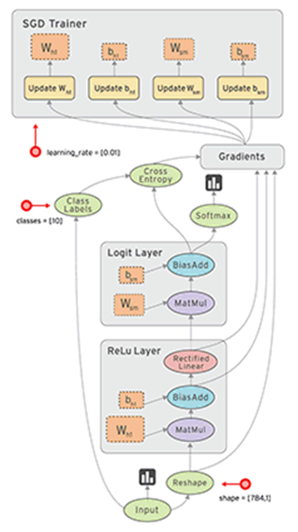

```python
bpc.Figure(bpc.ML01_IMG_01, 300)
```

## Installing TensorFlow

> - ### Anaconda Jupyter Notebook  
>   (VirtualEnv) pip install tensorflow

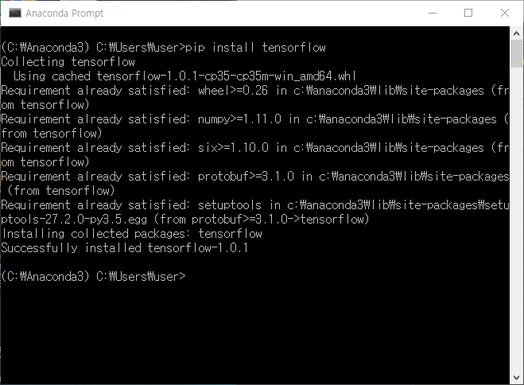

```python
bpc.Figure(bpc.ML01_IMG_02, 700)
```

> - ### PyCharm  
>   File > settings... Ctrl+Alt+S

[figure not shown]

```python
bpc.Figure(bpc.ML01_IMG_03, 1000)
```

## Check TF version

```python
# TensorFlow
import tensorflow as tf

# Helper libraries
import numpy as np
import matplotlib.pyplot as plt

tf.__version__
```

```
'1.8.0'
```

## Hello TensorFlow!

```
# tf.constant

Signature: tf.constant(value, dtype=None, shape=None, name='Const', verify_shape=False)
Docstring:
Creates a constant tensor.

The resulting tensor is populated with values of type `dtype`, as
specified by arguments `value` and (optionally) `shape` (see examples
below).

The argument `value` can be a constant value, or a list of values of type
`dtype`. If `value` is a list, then the length of the list must be less
than or equal to the number of elements implied by the `shape` argument (if
specified). In the case where the list length is less than the number of
elements specified by `shape`, the last element in the list will be used
to fill the remaining entries.
```

```python
# Create a constant op
# This op is added as a node to the default graph
hello = tf.constant("Hello, TensorFlow!")

# seart a TF session
sess = tf.Session()
```

```python
hello
```

```
<tf.Tensor 'Const:0' shape=() dtype=string>
```

```python
# run the op and get result
sess.run(hello)
```

```
b'Hello, TensorFlow!'
```

```python
result = sess.run(hello)
type(result)
```

```
bytes
```

[TIP] b 'String'

> - 'b' indicates Bytes literals.
> - 참조 : [What does the 'b' character do in front of a string literal?](http://stackoverflow.com/questions/6269765/)

```python
type(hello)
```

```
tensorflow.python.framework.ops.Tensor
```

```python
type(sess)
```

```
tensorflow.python.client.session.Session
```